# Section 4: Data visualisation

Authored by Masumi Stadler for the ÈcoLac fall workshop 26-28th October 2018

Parts of this tutorial are adapted from an workshop created by [Taylor Dunivin](http://taylordunivin.com/) for the Explorations in Data Analyses for [Metagenomic Advances in Microbial Ecology (EDAMAME) workshop 2018](http://www.edamamecourse.org/). The data used for the last challenge is also a data set from the [Ashley Shade Lab](http://ashley17061.wixsite.com/shadelab) of the Michigan State University.

This tutorial is licensed under a [Creative Commons Attribution 4.0 International License](http://creativecommons.org/licenses/by/4.0/).

*Share, adapt, and attribute please!*

Ploting is a vital part of research. There are several ways of plotting in R. Plotting with the `base` package is popular with the ‘traditional’ R users, but personally, I prefer plotting with `ggplot2` because of it’s intuitive coding of plotting and makes life easier for people working with categories and colouring.

Let me first introduce you to some basic plotting with the built-in data set `iris`:

# Base plotting

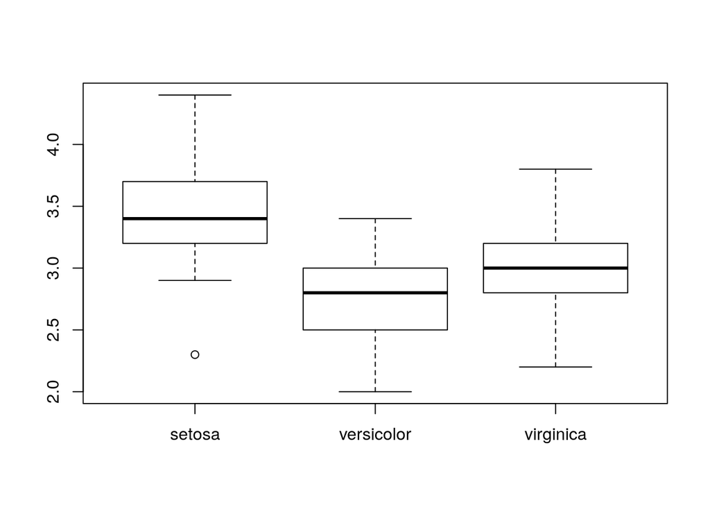

```r
# Plotting a continuous and a categorical variable creates a boxplot by default
plot(iris$Species, iris$Sepal.Width)
```

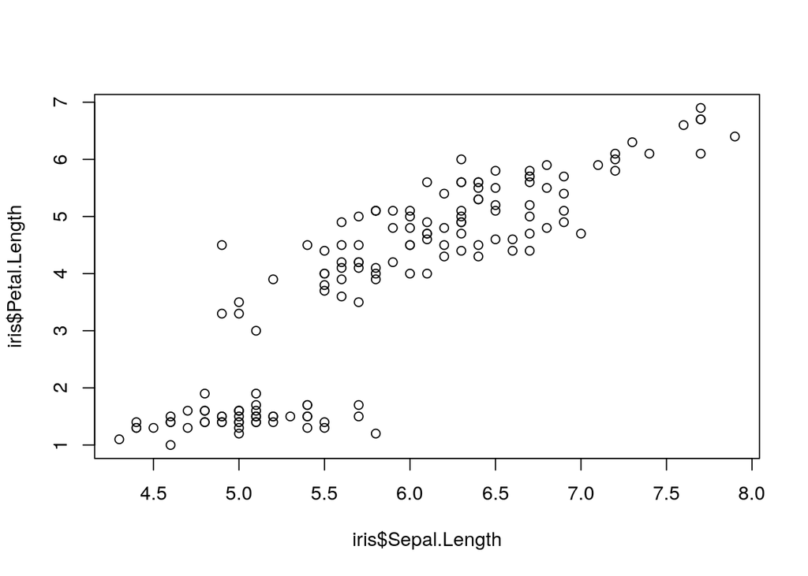

```r
# Plotting two numerical variables
plot(iris$Sepal.Length, iris$Petal.Length)
```

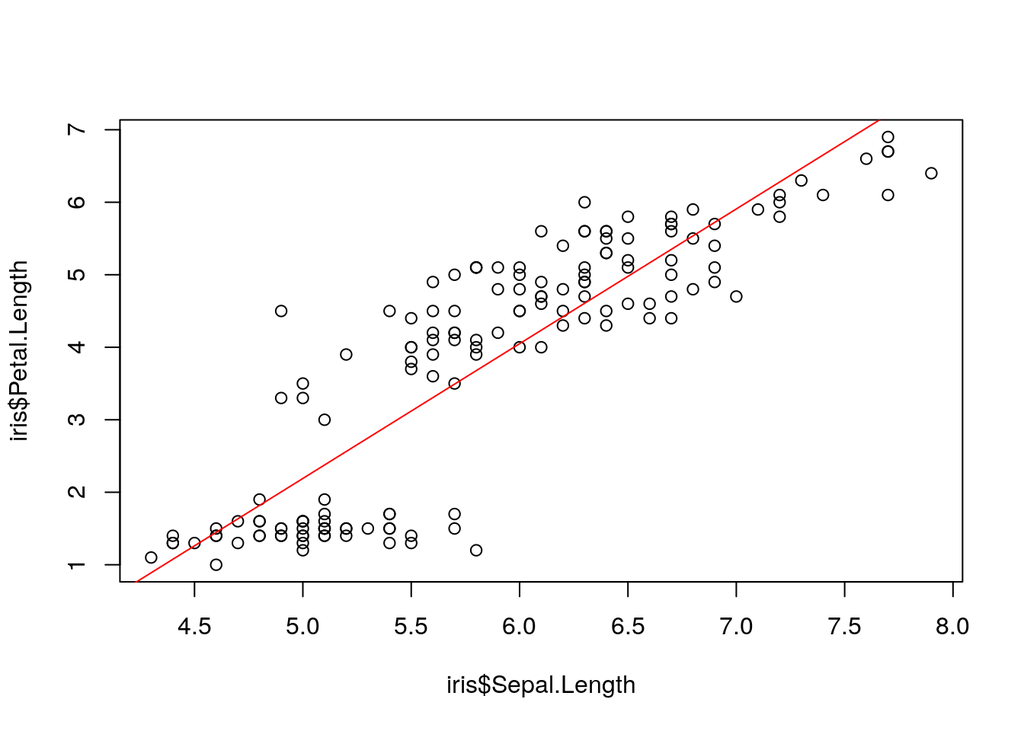

```r
# Adding a line from a linear model
iris.model <-lm(iris$Petal.Length ~ iris$Sepal.Length) # don't forget formulas are: y ~ x
plot(iris$Sepal.Length, iris$Petal.Length)
abline(iris.model, col = "red")
```

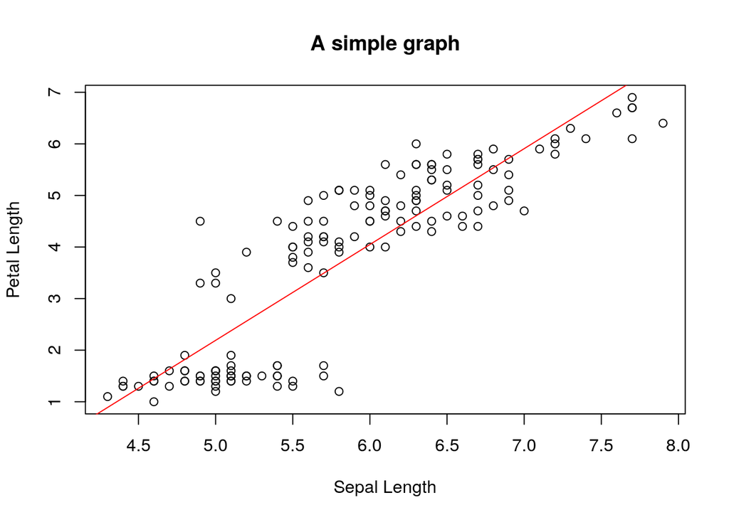

```r
# Adding title and changing axis names
plot(iris$Sepal.Length, iris$Petal.Length, xlab = "Sepal Length", ylab = "Petal Length")
abline(iris.model, col = "red")
title(main = "A simple graph")
```

You can see that plotting is sequential. You can add layers such as the line onto the plot by executing them together with the `plot()` function. Either mark them all together with your cursor and execute, or execute them sequentially starting with the `plot()` line.

For me, anything more complex than this becomes tedious in `base` plotting. Especially, for colouring, I’m not particularly happy. Some of you might think otherwise, but I learnt both at the beginning of learning R and I decided to get good at `ggplot2`. I would advice you: pick one and stick to it, most plots can be created in both ways.

You can find instructions how to use `base` plotting [here](https://www.harding.edu/fmccown/r/) and some advanced `base` plotting [here](https://www.cyclismo.org/tutorial/R/intermediatePlotting.html).

I will focus on `ggplot2` today.